# logistic regression in R

[output not shown]

[output not shown]

[output not shown]

[output not shown]

[output not shown]

[output not shown]

[output cut: 36 more lines]

[output not shown]

[output not shown]

[output not shown]

[output not shown]

[output not shown]

[output not shown]

[output not shown]

[output cut: 39 more lines]

[output not shown]

[output not shown]

[output not shown]

[output not shown]

[output not shown]

[output not shown]

[output not shown]

[output cut: 39 more lines]

[output not shown]

[output not shown]

[output not shown]

[output not shown]

[output not shown]

[output not shown]

[output not shown]

[output cut: 40 more lines]

[output not shown]

[output not shown]

[output not shown]

[output not shown]

[output not shown]

[output not shown]

[output not shown]

[output cut: 39 more lines]

[output not shown]

[output not shown]

[output not shown]

[output not shown]

[output not shown]

[output not shown]

[output not shown]

[output cut: 41 more lines]

[output not shown]

[output not shown]

[output not shown]

[output not shown]

[output not shown]

[output not shown]

[output not shown]

[output cut: 36 more lines]

[output not shown]

[output not shown]

[output not shown]

[output not shown]

[output not shown]

[output not shown]

[output not shown]

[output cut: 39 more lines]

[output not shown]

[output not shown]

[output not shown]

[output not shown]

[output not shown]

[output not shown]

[output not shown]

[output cut: 39 more lines]

[output not shown]

[output not shown]

[output not shown]

[output not shown]

[output not shown]

[output not shown]

[output not shown]

[output cut: 36 more lines]

[output not shown]

[output not shown]

[output not shown]

[output not shown]

[output not shown]

[output not shown]

[output not shown]

[output cut: 39 more lines]

[output not shown]

[output not shown]

[output not shown]

[output not shown]

[output not shown]

[output not shown]

[output not shown]

[output cut: 39 more lines]

[output not shown]

[output not shown]

[output not shown]

[output not shown]

[output not shown]

[output not shown]

[output not shown]

[output cut: 40 more lines]

[output not shown]

[output not shown]

[output not shown]

[output not shown]

[output not shown]

[output not shown]

[output not shown]

[output cut: 39 more lines]

[output not shown]

[output not shown]

[output not shown]

[output not shown]

[output not shown]

[output not shown]

[output not shown]

[output cut: 42 more lines]

[output not shown]

[output not shown]

[output not shown]

[output not shown]

[output not shown]

[output not shown]

[output not shown]

[output cut: 44 more lines]

[output not shown]

[output not shown]

[output not shown]

[output not shown]

[output not shown]

[output not shown]

[output not shown]

[output cut: 39 more lines]

[output not shown]

[output not shown]

[output not shown]

[output not shown]

[output not shown]

[output not shown]

[output not shown]

[output cut: 41 more lines]

[output not shown]

[output not shown]

[output not shown]

[output not shown]

[output not shown]

[output not shown]

[output not shown]

```r
t2 <- Sys.time()
```

see the time it took in the program above

```r
print(t2 - t1)
```

```
Time difference of 6.707857 hours
```

check the obtained test statistics (difference of deviances under null hypothesis)

```r
all_diff_dev
```

```
  [1]  1.9381910  1.7480975  2.3420490  3.2027210  4.3697988  0.6623808  4.3700064
  [8]  9.0268924  3.6120066  1.9054296  4.0184261  3.6684572  0.7034733  0.5657330
 [15]  3.3130909  3.7219868  2.3792747  1.2373208  4.2460639  4.5948529  1.5030411
 [22]  7.3258433  0.9536131  6.8977073  3.5497533  0.6936764  0.5390546  1.9184882
 [29]  4.1445590  3.6616851  2.2832457  4.3023398  1.7471050  1.2197384  3.7890307
 [36]  2.5618596  2.4976232  1.3526965  3.5333621  4.7238609  2.6153803  5.1147802
 [43]  5.0515245  1.5909919  3.4469516  1.0705867  1.5231113  3.7495475  1.9434600
 [50]  1.8760487  0.8240173  2.5738939  7.8505480  6.7499528  1.7391138  6.4618781
 [57]  2.4778713  4.1582171  2.9072518  0.9840018  6.9160715  1.9159471  2.6105084
 [64]  2.2038251  2.2161749  3.0720999  1.3727700  4.7920974  2.2241120  0.4109148
 [71]  5.5497476  6.0626037  3.9526611  1.1318566 -4.7701320  0.5517935 10.3379975
 [78]  3.4080138  1.0856793  2.1519753  8.6686511  3.0296243  2.8474683  1.2483609
 [85]  1.0740355  4.3560009  6.8246136  0.6471198  1.0729649  1.7336785  3.7976104
 [92]  5.9306906  2.1982596  4.7464925  2.8207246  1.6373543  1.5800445  2.2295758
 [99]  0.8656368  4.9089926  5.2353638  3.5617567  4.8156330  1.5315532  0.8417638
[106]  3.5360809  5.8797993  2.7363262  9.7785880  2.1303236 10.3359226  3.8726076
[113]  4.3332719  1.6448432  6.7379275  0.7907311  3.0569768  8.1256251  3.5460952
[120]  3.8023585  1.4894579 12.8925090  3.5714479  1.4498209  4.6101877  0.8416671
[127]  3.0409455  7.4721354  4.0397089  1.5552416  2.7447311  5.9917447  3.7832018
[134]  1.8026676  2.5639796  2.1137785  2.0052233  4.9124938  5.1685265  2.7656397
[141]  6.3986432  2.1088142  2.8303355  2.2582191  3.8342035  1.9219152  4.8968762
[148]  0.7705354  8.3103932  1.6680758
```

save check the obtained test statistics

```r
save(all_diff_dev, file=paste0("mcmc_results_LR/all_diff_dev_",
                                         formatC(k, width = 4, flag = "0"),
                                         ".RData"))
```

Check the distribution. Note that sometimes it includes minus values which are results from incorrect MCMC sampling. They should be removed.

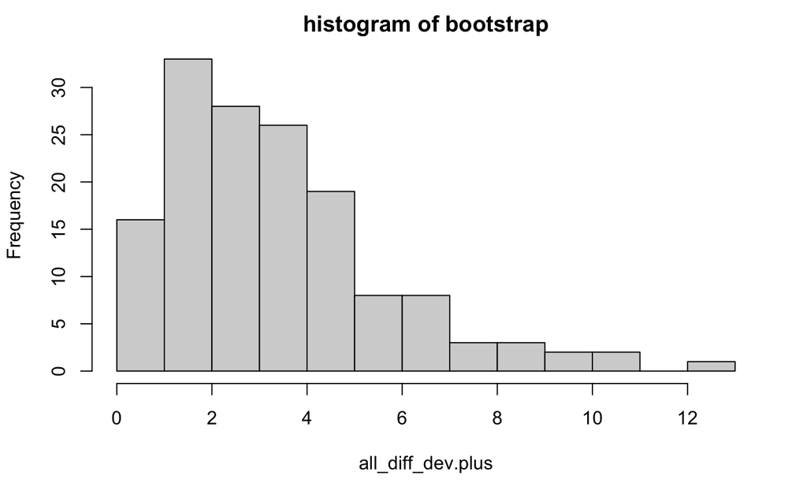

```r
all_diff_dev.plus <- all_diff_dev[all_diff_dev > 0]
hist(all_diff_dev.plus,main="histogram of bootstrap")
```

### compare the bootstrap and theoretical distribution

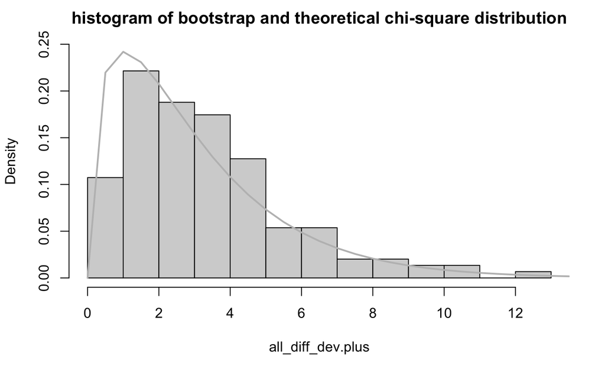

```r
histogram <- hist(all_diff_dev.plus,
                  breaks=seq(from=0, to=13.5, by=1),
                  ylim=c(0,.25),
                  freq=FALSE,
                  main="histogram of bootstrap and theoretical chi-square distribution")

LR <- seq(from=0, to=13.5, by=0.5)
d_theo <- dchisq(LR,df=3)
lines(x=LR,
      y=d_theo, # density
      lwd = 2, # thickness of line
      col = "gray")
```

### compare cumulative distribution

get cumulative distribution at some points of the distribution of the bootstrap

```r
LR <- seq(from=0, to=7.5, by=0.5)

q_bootstrap <- numeric(length(LR))
for(i in 1:length(LR)){
  q_bootstrap[i] <- 1 - (length(all_diff_dev.plus[all_diff_dev.plus> LR[i]])/length(all_diff_dev.plus))
}

#bootstrap distribution
q_bootstrap
```

```
 [1] 0.000000000 0.006711409 0.107382550 0.187919463 0.328859060 0.436241611 0.516778523
 [8] 0.570469799 0.691275168 0.758389262 0.818791946 0.845637584 0.872483221 0.892617450
[15] 0.926174497 0.939597315
```

get cumulative distribution at some points of the theoretical distribution

```r
#theoretical distribution
q_theo <- pchisq(LR,df=3)
q_theo
```

```
 [1] 0.00000000 0.08110859 0.19874804 0.31772967 0.42759330 0.52470892 0.60837482 0.67923788
 [9] 0.73853587 0.78770971 0.82820286 0.86136138 0.88838977 0.91033750 0.92810223 0.94244155
```

compare the two cumulative distributions by QQ-plotting

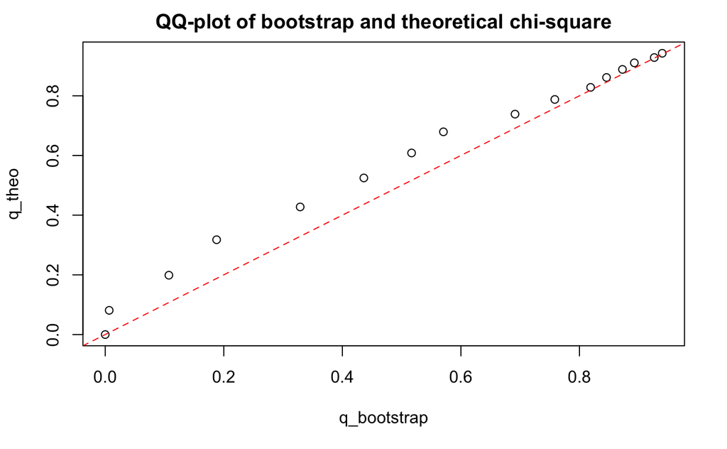

```r
plot(q_bootstrap,q_theo,
     main="QQ-plot of bootstrap and theoretical chi-square")
abline(0,1,col="red",lty=2)
```